# Final Project

Yudan Zhang

Due Date: Dec. 14, 2020

## Load Packages:

```r
# Set up:
library(rvest)
library(tidyverse)
library(genius)
library(tidytext)
library(gridExtra) # grid.arrange function from the gridExtra package will be used in Graph3 to combine 4 different graphs
data("stop_words") # will be used for filter out "stop-words"
data("sentiments") # will be used in Graph4-6
```

## Data Access:

```r
# Scrape the Grammy nominated Records of the Year from 1980 through 2019
webpage <- read_html("https://en.wikipedia.org/wiki/Grammy_Award_for_Record_of_the_Year")
```

## Scrape the Grammy nominated Records of the Year from 1980 through 2019:

```r
# Scrape and create table of records from 1980s:
# copy xpath for table of 1980s
XPATH80 <- '/html/body/div[3]/div[3]/div[5]/div[1]/table[5]'
# run the following to create table of songs from 1980s
table_1980 <-
  webpage %>%
  html_nodes(xpath = XPATH80) %>%
  html_table(fill = TRUE)
d1980 <- table_1980[[1]]
# can use head() to see what how table should like like after scraping - should have 60 obs and 4 variables

# Scrape and create table of records from 1990s:
# copy xpath for table of 1990s
XPATH90 <- '/html/body/div[3]/div[3]/div[5]/div[1]/table[6]' # I change table table[5] to table [6] to get access to 1990s table.
# run the following to create table of songs from 1990s:
table_1990 <-
  webpage %>%
  html_nodes(xpath = XPATH90) %>%
  html_table(fill = TRUE)
d1990 <- table_1990[[1]]
# d1990 should have 60 obs and 4 variables

# Scrape and create table of records from 2000s:
# copy xpath for table of 2000s
XPATH00 <- '/html/body/div[3]/div[3]/div[5]/div[1]/table[7]' # I change table table[6] to table [7] to get access to 2000s table.
# run the following to create table of songs from 2000s:
table_2000 <-
  webpage %>%
  html_nodes(xpath = XPATH00) %>%
  html_table(fill = TRUE)
d2000 <- table_2000[[1]]
# d2000 should have 60 obs and 4 variables

# Scrape and create table of records from 2010s:
# copy xpath for table of 2000s
XPATH10 <- '/html/body/div[3]/div[3]/div[5]/div[1]/table[8]' # I change table table[7] to table [8] to get access to 2010s table.
# run the following to create table of songs from 2010s:
table_2010 <-
  webpage %>%
  html_nodes(xpath = XPATH10) %>%
  html_table(fill = TRUE)
d2010 <- table_2010[[1]]
# d2010 should have 64 obs and 4 variables
```

## Edit and Clean Part:

```r
# combine all the tables together
d1<- merge(d1980,d1990, all = TRUE)
d2 <- merge(d2000,d2010,all = TRUE)
d<- merge(d1,d2,all= TRUE)

# edit and clean Part:
ROY<-na.omit(d)%>% #remove the NAs
  select("Year[I]","Record","Artist(s)") %>% # select needed variables
  rename(year="Year[I]",track="Record",artist="Artist(s)")%>% # rename variables
  mutate(year= gsub("[ ]|\\[.*$", "", year))%>% # remove the bracketed numbers from each year value
# create new variable, decade, for later use
  mutate(decade= ifelse(year %in% 1980:1989,"1980s", # if 1980<=year<= 1989 return "1980s", otherwise
                           ifelse(year %in% 1990:1999,"1990s", # if 1990<=year<= 1999 return "1990s", otherwise
                                  ifelse(year %in% 2000:2009,"2000s","2010s")))) # if 2000<=year<= 2000 return "2000s", otherwise "2010s"
# # can use head(ROY) to see what how table should like like after clear - should have 204 obs and 4 variables
```

## remove the stop_words and the extra 11:

```r
# One with all the lyrics (words)
verse_words <- lyrics %>%
  unnest_tokens(word, lyric) # break the lyrics into individual words

# create a list of the 11 words that are not contained in the "stop_words"
Add_stop_words<-c("ba", "du", "yeah", "da", "ya", "ooh", "gonna", "na","uh", "la","hol")

# Another one without all the "stop words".
ft <- verse_words %>%
  filter(!word %in% Add_stop_words)%>% # filter out the 11 words that are not included in this stop_words data frame:
  anti_join(stop_words) #filters out the stop_words using the 'stop_word' data frame from tidytext package
```

## Narrative Part for base data frame:

First, I access the data for each decade by changing the corresponding number in the table [] for each decade. Second, I use merge() to combine all the tables from different decades together. Then, use na.omit() to remove NAs, use rename() to remove the [I] from Year, change Record to track and Artist(s) to artist. Use gsub() to remove the bracketed numbers from each year value and create a new variable, decade, by ifelse(). Last, I use unnest_tokens() to break the lyrics into individual words and use filter() and anti_join() to get rid off the “stop_word” from tidytext package and the 11 words are not contained in it.

## Data Visualization:

### Graph 1: Boxplot that displays the words per song for each decade before removing stop_words.

As we can see, the 2000s has the biggest range between the upper quartile and lower quartile among the four decades. So, maybe we can get the conclusion that Grammy-nominated songs in the 2000s has the most words per song. However, we use the data set that contains those “stop words” to create this graph so we cannot tell those words are “quality” words.

```r
# table used for creating Graph1:
Graph1<-verse_words %>% # use the one before removing stop_words
  group_by(decade,track)%>%
  mutate(word_count= n())%>% # get the total number of words per song per decade
  select(decade,word_count)%>%
  distinct()%>% # obtain one record per song
  ungroup()
```

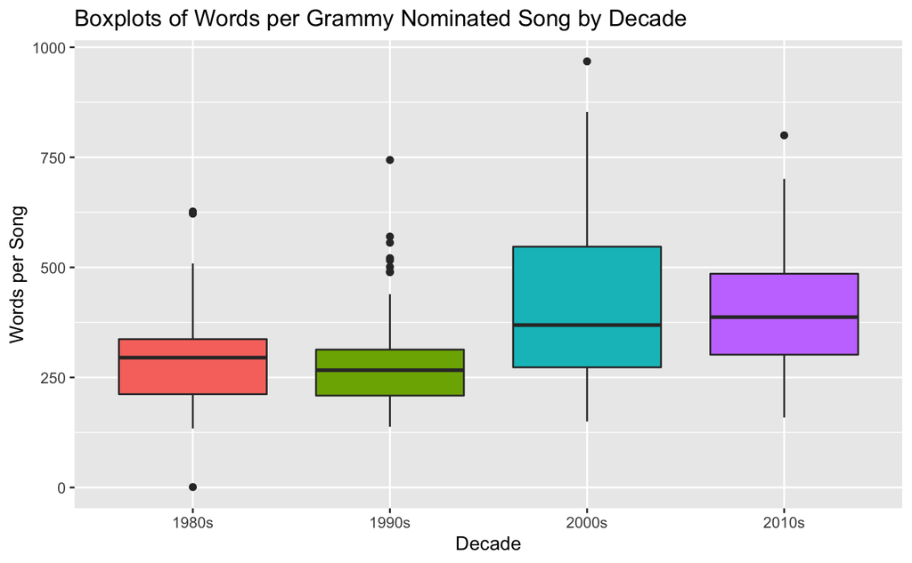

```r
# codes for graphing Graph1:
ggplot(data= Graph1, aes(x=decade, y=word_count))+
  geom_boxplot(aes(fill=decade))+
  labs(x="Decade",y="Words per Song")+
  ggtitle("Boxplots of Words per Grammy Nominated Song by Decade")+
  theme(legend.position = "none")
```

### Graph 2: Column graph of the top ten words overall.

From the second graph, we can see the ten most popular words from Grammy-nominated songs from 1980 - 2019 are “love”, “baby”, “night”, “wanna”, “feel”, “time”, “heart”, “life”, “shake” and “world”. This graph uses the data set after filtering those “stop words” so I believe the top ten words are “quality” words. Also, I noticed that the count of the word “love” is much more than the other words in this list. My guess about the reason behinds it is that people are more willing to express their love and kindness to others than other emotion.

```r
# table used for creating Graph2:
Graph2 <-ft %>%
  group_by(word) %>%
  summarise(count = n()) %>%
  arrange(desc(count))%>%
  top_n(10)
```

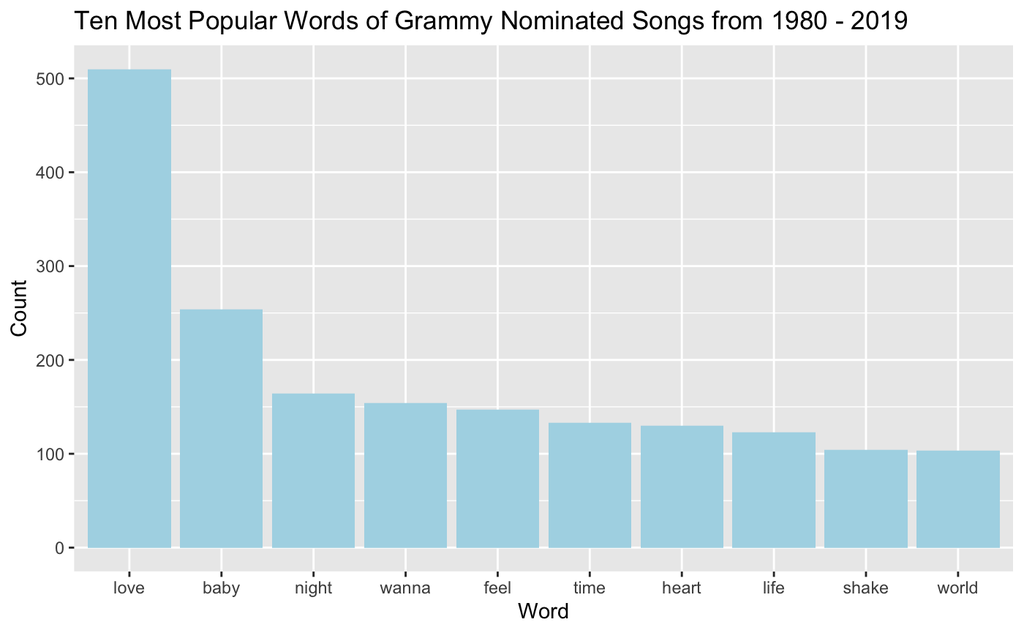

```r
# codes for graphing Graph2:
Graph2%>%
  ggplot(aes(x=reorder(word,-count),y=count)) + # reorder() to set the columns in descending order; "-count": descending from left to right.
  geom_col(fill="light blue")+ # use a color besides the default
  labs(x="Word",y="Count")+
  ggtitle("Ten Most Popular Words of Grammy Nominated Songs from 1980 - 2019")+
  theme(legend.position = "none")
```

### Graph 3: Column graph of top ten words by decade.

From the third graph, we can see that word “love” is the top one for the four dacades which matches what I get from graph 2. Also, there are several words in the top ten list for each decade such as “baby” which are also in the Ten Most Popular words in graph2. More interestingly, I find that, in the 2010s, the use of “negative words” such as “slay” and “bitch” is more usual than in the previous decades. This phenomenon is probably due to the change in trends and language habits. People may express their negative emotions more aggressively than before.

```r
# creating one graph for 1980s:
Graph1980s <-ft %>%
  filter(decade=="1980s")%>%
  count(word, sort = TRUE) %>%
  filter(n >= 3) %>% # find the meaningful words which have count>=3
  top_n(10) # only want the top 10 words
```

```r
# creating one graph for 1990s:
Graph1990s <-ft %>%
  filter(decade=="1990s")%>%
  count(word, sort = TRUE) %>%
  filter(n >= 3) %>%
  top_n(10)
```

```r
# creating one graph for 2000s:
Graph2000s <-ft %>%
  filter(decade=="2000s")%>%
  count(word, sort = TRUE) %>%
  filter(n >= 3) %>%
  top_n(10)
```

```r
# creating one graph for 2010s:
Graph2010s <-ft %>%
  filter(decade=="2010s")%>%
  count(word, sort = TRUE) %>%
 filter(n >= 3) %>%
  top_n(10)
```

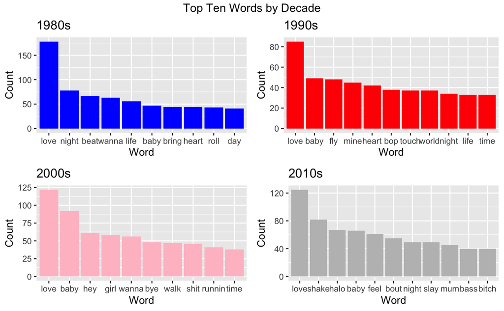

```r
# Arranging them into one graph of two rows by grid.arrange() from the gridExtra package.
p80s<-ggplot(Graph1980s, aes(x=reorder(word,-n),y=n)) + geom_col(fill="blue")+ labs(x="Word",y="Count")+ggtitle("1980s")+ theme(legend.position = "none")

p90s<-ggplot(Graph1990s, aes(x=reorder(word,-n),y=n)) + geom_col(fill="red")+ labs(x="Word",y="Count")+ggtitle("1990s")+ theme(legend.position = "none")

p00s<-ggplot(Graph2000s, aes(x=reorder(word,-n),y=n)) + geom_col(fill="pink")+ labs(x="Word",y="Count")+ggtitle("2000s")+ theme(legend.position = "none")

p10s<-ggplot(Graph2010s, aes(x=reorder(word,-n),y=n)) + geom_col(fill="grey")+ labs(x="Word",y="Count")+ggtitle("2010s")+ theme(legend.position = "none")

grid.arrange(p80s, p90s, p00s, p10s,top="Top Ten Words by Decade")
```

### Create a new sentiment data set for Graph4-6:

```r
New_sentiment<- sentiments %>% # Get data sentiment from the tidytext package
# create a new variable, score,which equals to 1 for sentiment = positive and 0 for sentiment = negative.
  mutate(score=ifelse(sentiment=="positive",1,0))

# left_join the filtered data frame(ft) with the data frame 'sentiments' from the tidytext package. Joining the match word from New_sentiment to ft.
Net_sentiment<-ft%>%
  left_join(New_sentiment,by="word")%>%
  filter(!is.na(score)) # remove NAs
```

### Graph 4: Bar graph of net sentiment score by year with the bars a different color across decade

From the fourth graph, we can see the net sentiment score varies over years. The higher the net sentiment score is the more positive those songs are. There is a relatively high value in the 2010s, which may have an influence on the mean sentiment score as well. What’s more, since I also major in economics, I would like to talk about the relationship between GDP and the net sentiment score. I find that the great falls in economics also reflect in some falls in the net sentiment score. I will talk about this more in my presentation.

```r
# table used for creating Graph4:
Graph4 <- Net_sentiment %>%
  # group_by the variable for later use
  group_by(year,decade)%>%
  # the total sentiment score for each year
  summarise(total_score=sum(score))%>%
  select(decade,year,total_score)
```

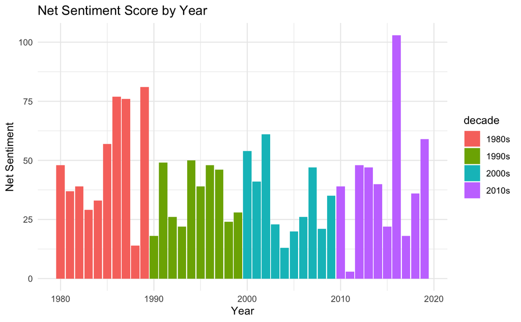

```r
# codes for graphing Graph4:
Graph4%>%
  ggplot(aes(x=as.numeric(year), y= total_score,fill = decade)) + # I want the type of variable year be numerical so that only the decade will be present on the x-axis instead of each year.
  geom_bar(stat = "identity") +
  labs(x="Year",y="Net Sentiment")+ggtitle("Net Sentiment Score by Year")+
  theme_minimal()# remove edge around the graph and set the background as white.
```

### Graph 5: Bar graph of mean sentiment score per decade

We can see that the 1980s has the highest mean sentiment score. Probably people at that time were more positive and enjoyed their life so much. This result also matches what the net sentiment score shows. I think the max value in the 2010s leads its mean score to increase a lot and make the 2010s become the second highest decade in term of the mean sentiment score among the four decades.

```r
# table used for creating Graph5:
Graph5 <- Net_sentiment %>%
  # group_by the variable for later use
  group_by(decade)%>%
  # get the mean sentiment score per decade
  summarise(mean_score=(sum(score)/10))%>%
  select(decade,mean_score)
```

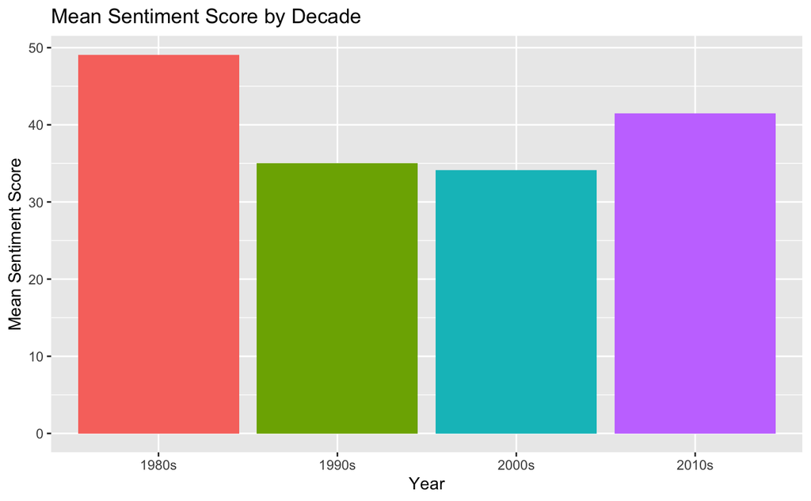

```r
# codes for graphing Graph5:
Graph5%>%
  ggplot(aes(x= decade, y= mean_score,fill = decade)) +
  geom_bar(stat = "identity") +
  labs(x="Year",y="Mean Sentiment Score")+ggtitle("Mean Sentiment Score by Decade")+ theme(legend.position = "none")
```

### Graph 6:Point graph of net sentiment scores versus year with a single regression line.

In the sixth graph, the points match the values in graph4. The regression line added in graph6 is used to find out the relationship between the sets of data in statistics. In the graph6, there is a smooth regression line with a few outliers. By simply looking at the regression line, it also fits the trend in graph4.

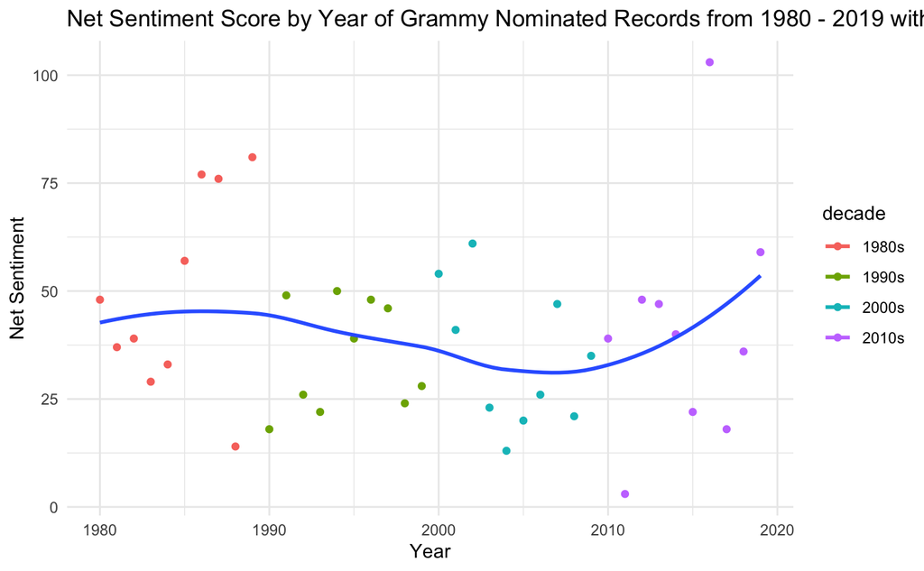

```r
# Ask for the same thing as Graph4 so I just use the table for Graph4 and add a regression line in the Graph6.
ggplot(data=Graph4,aes(x=as.numeric(year), y=total_score,color= decade))+ # Only want the decades showed on the x-axis so change the type of variable year to numerical.
  geom_point() +
  stat_smooth(aes(group=1),se=FALSE)+ # I want a smooth regression line by group=1 and without confidence interval by se=FALSE.
  labs(x="Year",y="Net Sentiment")+ggtitle("Net Sentiment Score by Year of Grammy Nominated Records from 1980 - 2019 with Linear Model Fit")+
  theme(legend.position = "right")+ # Set the legend on the right
  theme_minimal()# remove edge around the graph and set the background as white.
```

## Zoom link of My Presentation:

https://psu.zoom.us/rec/share/u1mVOPivqs4VjIlRtWCxZ0qsIio7I7Ue9FG-TVIMwxtCk30MhcTxMWKLsBvePR5Y.Yamk8Gik_YrNPUtG